# NLP CHEATSHEET

Shawn Wang

2026-04-08

# DATA WRANGLING

## Functions to add numbers

```r
#function to add 2 numbers

add_func <- function(x, y) {

  #add them together
  sum <- x + y
  return(sum)
}


#EXAMPLE: 3 + 4
add_func(3, 4)
```

```
## [1] 7
```

## Function to mean 2 numbers

```r
mean_func <- function(x, y) {

  #take the sum
  sum <- x + y

  #divide by 2
  mean <- sum / 2
  return(mean)
}


#EXAMPLE: average of 3 and 4

mean_func(3, 4)
```

```
## [1] 3.5
```

# TEXT CLEANING

## Function to remove any word from a string

```r
#old_Word is the word you want to replace
#replacement_Word is the word you want to replace it with
#takes a string returns a string
replace_func <- function(string, old_Word, replacement_Word) {

  x <- string
  x_clean <- x %>%
    gsub(pattern = old_Word, replacement = replacement_Word)

  return(x_clean)


}


#EXAMPLE: removing "little" from mary had a little lamb:
test_string <- "mary had a little lamb"
replace_func(string = test_string, old_Word = "little", replacement_Word = "")
```

```
## [1] "mary had a  lamb"
```

## Function to remove special characters

```r
#takes a string returns a string
remove_special_func <- function(myString) {


  #replaces punctuation and special characters
  x_clean <- gsub("[[:punct:]]", "", myString)


  return(x_clean)


}


#EXAMPLE: removing punctuation marks from messy string:
test_string <- "ma';ry had$ #@a litt#%le lam%^b"
remove_special_func(test_string)
```

```
## [1] "mary had a little lamb"
```

## Function to split string into data frame, one word per row

```r
#takes a string returns a data frame
split_string <- function(x) {

  #convert to a data frame first
  cleaned_x <- data.frame(string = x) %>%
    separate_longer_delim(string, delim = " ") %>% #pivots to long format based on delimeter of space
    filter(string != "") #filters so that empty rows are deleted
  return(cleaned_x)

}


#EXAMPLE: splitting and unlisting "mary had a little lamb"
test_string <- "mary had a little lamb"
split_string(test_string)
```

| x |
| --- |
| mary |
| had |
| a |
| little |
| lamb |

## Remove numbers

```r
#takes a string returns a string
remove_numbers <- function(x) {

  #uses regex to remove any numbers from a string
  x_clean <- x %>%
    gsub(pattern = "\\d+", replacement = "")
  return(x_clean)

}


#EXAMPLE: removing numbers from messy string
test_string <- "mar56854864y h56ad3412 a346 li346tt34634le lam346b"
remove_numbers(test_string)
```

```
## [1] "mary had a little lamb"
```

## Remove non-alphabetic characters, numbers, punctuation

```r
keep_alphab <- function(x) {

  #uses regex to remove any numbers from a string
  x_clean <- x %>%
    mutate(string = gsub(pattern = "[^a-zA-Z]", replacement = "", string))



  return(x_clean)

}


#EXAMPLE: removing all these from messy string as a split and unlisted data frame
test_string <- "ma245ry[][]][] ha]][d a 78990lit35567%#$tl87e[][] lam36;;'[][537b"
test_string_split <- split_string(test_string)
keep_alphab(test_string_split)
```

| x |
| --- |
| mary |
| had |
| a |
| little |
| lamb |

## Full cleaning genie

Revamped 2.23.26

```r
shawn_genie <- function(x, wordcol) {


  library(stringr)
  library(stringi)
  load(url("https://github.com/Reilly-ConceptsCognitionLab/reillylab_publicdata/blob/main/replacements_25.rda?raw=true"))
  load(url("https://github.com/Reilly-ConceptsCognitionLab/reillylab_publicdata/blob/main/Temple_stops25.rda?raw=true"))


  #what are the column names that are not the wordcol?
  x_metadata <- setdiff(colnames(x), wordcol)

  #some basic standardiziation
  data_prep_standard <- x %>%
    dplyr::mutate(text_initialSplit = stringi::stri_enc_toutf8(.[[wordcol]])) %>% #convert to UTF
    dplyr::mutate(text_initialSplit = ifelse( #standardize apostrophes
      is.na(text_initialSplit), NA_character_,
      stringi::stri_replace_all_regex(
        text_initialSplit,
        "[\u2018\u2019\u02BC\u201B\uFF07\u0092\u0091\u0060\u00B4\u2032\u2035]",
        "'")))


  #split the text first then delete the original column
  data_prep_split <- data_prep_standard %>%
    tidyr::separate_rows(text_initialSplit, sep = "[[:space:]]+") %>%
    dplyr::filter(!is.na(text_initialSplit))



  #do cleaning on individual text rows
  #RETAIN apostrophes
  data_prep_convert <- data_prep_split %>%
    dplyr::mutate(text_prep = tolower(as.character(text_initialSplit)),
                  text_prep = tm::stripWhitespace(text_prep),
                  text_prep = stringr::str_replace_all(text_prep, "^'+|'+$", ""),
                  text_prep = stringr::str_replace_all(text_prep, "[/-]", " "))

  #load in the list of contractions that we want to replace
  replacements_25 <- replacements_25 %>%
    dplyr::mutate(word = stringi::stri_replace_all_regex(word,
                                                         "[\u2018\u2019\u02BC\u201B\uFF07\u0092\u0091\u0060\u00B4\u2032\u2035]",
                                                         "'",
      vectorize_all = FALSE
    ))


  contractions_list <- replacements_25$word


  #replace contractions
  data_prep_contractReplace <- data_prep_convert %>%
    dplyr::left_join(replacements_25, by = c("text_prep" = "word")) %>%
    dplyr::mutate(text_prep = dplyr::case_when(
      is.na(text_prep) | text_prep == "" ~ NA_character_,
      !is.na(replacement) ~ replacement,
      TRUE ~ text_prep
    )) %>%
    dplyr::select(-c(wordcol, replacement)) %>%
    tidyr::separate_rows(text_prep, sep = "[[:space:]]+")


  data_prep_clean <- data_prep_contractReplace %>%
    dplyr::mutate(
      word_clean = text_prep,
      word_clean = gsub(pattern = "[^a-zA-Z]", replacement = "", word_clean), #uses regex to remove any numbers from a string
      word_clean = tm::stripWhitespace(word_clean)
    ) %>%
    dplyr::filter(!is.na(word_clean) & word_clean != "") %>%
    dplyr::filter(!(word_clean %in% c("i","ii","iii","iv","v","vi","vii","viii","ix","x")))



  data_prep_lemma <- data_prep_clean %>%
    dplyr::mutate(word_lemma = textstem::lemmatize_strings(word_clean)) %>%
    dplyr::mutate(
      word_lemma = word_lemma,
      word_lemma = gsub(pattern = "[^a-zA-Z]", replacement = "", word_lemma), #uses regex to remove any numbers from a string
      word_lemma = tm::stripWhitespace(word_lemma)
    ) %>%
    dplyr::filter(!is.na(word_lemma) & word_lemma != "")


  stopwords <- Temple_stops25$word
  data_prep_stopRemove <- data_prep_lemma %>%
    dplyr::mutate(
      is_stopword = ifelse( #create new variable identifying which words are stopwords
        is.na(word_lemma), NA, #if empty do nothing
        word_lemma %in% stopwords) #if not empty then TRUE if stopword, FALSE if not stopword
    ) %>%
    dplyr::filter(is_stopword == FALSE) #keep only the words that are NOT stopwords


  data_final <- data_prep_stopRemove %>%
    dplyr::select(dplyr::all_of(x_metadata), !!wordcol := word_lemma)




  return(data_final)

}


# EXAMPLE:


#run cleaning genie
unabomb_df <- data.frame(ID = "TK", text = unabomb_raw) %>%
  dplyr::summarize(ID = unique(ID),
            text = paste0(unabomb_raw, collapse = " "))

unabomb_clean <- shawn_genie(unabomb_df, "text")
unabomb_clean_df <- shawn_genie(unabomb_df, "text")
```

## Convert into corpus, tokenize, and turn into document feature matrix

```r
#corpus() is used to turn a text data frame with one row per document, columns for metadata then one column for text
unabomb_corpus <- corpus(unabomb_clean_df,
                         doc_id_field = "author",
                         text_field = "text")

#tokenize
tokens_unabomb <- tokens(unabomb_corpus)

#turn the tokenized object into document feature matrix
dfm_unabomb <- dfm(tokens_unabomb)

names(unabomb_corpus) <- "Unabomber Manifesto"
```

# CORPUS STATISTICS

## Getting some basic off-the-shelf statistics about your corpus

dfm_unabomb has to be a document frame matrix type object here:

```r
#lexical diversity, these are all different measures
print(textstat_lexdiv(dfm_unabomb, measure = c("TTR", "C", "R", "CTTR", "U", "S", "K", "I", "D", "Vm", "Maas"), log.base = 10))
```

```
##      document TTR  C R      CTTR  U  S K I  D Vm Maas lgV0 lgeV0
## 1       text1   1 NA 1 0.7071068 NA NA 0 0 NA  0   NA   NA    NA
## 2       text2   1 NA 1 0.7071068 NA NA 0 0 NA  0   NA   NA    NA
## 3       text3   1 NA 1 0.7071068 NA NA 0 0 NA  0   NA   NA    NA
## 4       text4   1 NA 1 0.7071068 NA NA 0 0 NA  0   NA   NA    NA
## 5       text5   1 NA 1 0.7071068 NA NA 0 0 NA  0   NA   NA    NA
## 6       text6   1 NA 1 0.7071068 NA NA 0 0 NA  0   NA   NA    NA
## 7       text7   1 NA 1 0.7071068 NA NA 0 0 NA  0   NA   NA    NA
## 8       text8   1 NA 1 0.7071068 NA NA 0 0 NA  0   NA   NA    NA
## 9       text9   1 NA 1 0.7071068 NA NA 0 0 NA  0   NA   NA    NA
## 10     text10   1 NA 1 0.7071068 NA NA 0 0 NA  0   NA   NA    NA
## 11     text11   1 NA 1 0.7071068 NA NA 0 0 NA  0   NA   NA    NA
## 12     text12   1 NA 1 0.7071068 NA NA 0 0 NA  0   NA   NA    NA
## 13     text13   1 NA 1 0.7071068 NA NA 0 0 NA  0   NA   NA    NA
## 14     text14   1 NA 1 0.7071068 NA NA 0 0 NA  0   NA   NA    NA
```

[output cut: 7129 more lines]

## Table of lexical characteristcs pre/post

```r
#summary gives you the types and tokens
summary(unabomb_corpus)
```

| Text | Types | Tokens | Sentences | ID |
| --- | --- | --- | --- | --- |
| Unabomber Manifesto.1 | 1 | 1 | 1 | TK |
| Unabomber Manifesto.2 | 1 | 1 | 1 | TK |
| Unabomber Manifesto.3 | 1 | 1 | 1 | TK |
| Unabomber Manifesto.4 | 1 | 1 | 1 | TK |
| Unabomber Manifesto.5 | 1 | 1 | 1 | TK |
| Unabomber Manifesto.6 | 1 | 1 | 1 | TK |
| Unabomber Manifesto.7 | 1 | 1 | 1 | TK |
| Unabomber Manifesto.8 | 1 | 1 | 1 | TK |
| Unabomber Manifesto.9 | 1 | 1 | 1 | TK |
| Unabomber Manifesto.10 | 1 | 1 | 1 | TK |
| Unabomber Manifesto.11 | 1 | 1 | 1 | TK |
| Unabomber Manifesto.12 | 1 | 1 | 1 | TK |
| Unabomber Manifesto.13 | 1 | 1 | 1 | TK |
| Unabomber Manifesto.14 | 1 | 1 | 1 | TK |
| Unabomber Manifesto.15 | 1 | 1 | 1 | TK |
| Unabomber Manifesto.16 | 1 | 1 | 1 | TK |
| Unabomber Manifesto.17 | 1 | 1 | 1 | TK |
| Unabomber Manifesto.18 | 1 | 1 | 1 | TK |
| Unabomber Manifesto.19 | 1 | 1 | 1 | TK |
| Unabomber Manifesto.20 | 1 | 1 | 1 | TK |
| Unabomber Manifesto.21 | 1 | 1 | 1 | TK |
| Unabomber Manifesto.22 | 1 | 1 | 1 | TK |
| Unabomber Manifesto.23 | 1 | 1 | 1 | TK |
| Unabomber Manifesto.24 | 1 | 1 | 1 | TK |
| Unabomber Manifesto.25 | 1 | 1 | 1 | TK |
| Unabomber Manifesto.26 | 1 | 1 | 1 | TK |
| Unabomber Manifesto.27 | 1 | 1 | 1 | TK |
| Unabomber Manifesto.28 | 1 | 1 | 1 | TK |
| Unabomber Manifesto.29 | 1 | 1 | 1 | TK |
| Unabomber Manifesto.30 | 1 | 1 | 1 | TK |

[output cut: 70 more lines]

```r
unabomb_raw_df <- data.frame( #creating a new data frame here to give it some info it wants
  author = "TK",
  doc_text = unabomb_raw
) %>%
  summarize(author = unique(author), #group by author - this might change when there are multiple works per author
            doc_text = paste(doc_text, collapse = " ")) #collapse the text all back into one cell for the corpus conversion
unabomb_raw_corpus <- corpus(unabomb_raw_df, doc_id_field = "author", text_field = "doc_text") #convert to corpus
summary(unabomb_raw_corpus) #take a look at type and tokens
```

| Text | Types | Tokens | Sentences | author |
| --- | --- | --- | --- | --- |
| text1 | 4849 | 38997 | 1792 | TK |

## Document Feature Matrix

You can also find the document feature matrix using topfeatures where you give it how many words you want:

```r
#print top 20 words
topfeatures(dfm_unabomb, 20)
```

```
##       have        not    society       much         as     system     people
##        435        310        263        261        245        235        225
##         do      power      human       make    leftist technology         so
##        213        170        141        134        132        127        123
##       need       only      other         no     social       many
##        121        118        110        104         98         98
```

# SENTIMENT ANALYSIS

## Merge with lookup tables:

We merge with a lookup table to assign indices to each word that exists in our corpus.

```r
#load in database from online
load(url("https://github.com/Reilly-ConceptsCognitionLab/reillylab_publicdata/blob/main/lookup_Jul25.rda?raw=true"))

#cut the database to the variables that we're interested in
lookup_small <- lookup_Jul25 %>% select(word, emo_arousal_b24, emo_intensity, emo_trust, emo_valence_b24, lex_AoA)

df_prep <- unabomb_clean %>% left_join(lookup_small, by = c("text" = "word"))
```

## Descriptive statistics of sentiment indices

describe() from psych package is an easy way of getting basic descriptive statistics from columns extracted from databases.

```r
df_prep %>%
  select(-text) %>%
  psych::describe() %>%
  select(mean, sd, median)
```

|  | mean | sd | median |
| --- | --- | --- | --- |
| ID* | 1.00 | 0.00 | 1.00 |
| emo_arousal_b24 | 2.75 | 1.73 | 2.31 |
| emo_intensity | 0.56 | 0.78 | 0.10 |
| emo_trust | 0.07 | 0.12 | 0.07 |
| emo_valence_b24 | 5.22 | 1.21 | 5.01 |
| lex_AoA | 7.20 | 2.69 | 6.89 |

# CORPUS PLOTS

## Lexical Dispersion Plot

Pick the words that you want to display on your dispersion plot:

[figure not shown]

```r
textplot_xray(
    kwic(tokens(unabomb_corpus), pattern = "capitalism"),
    kwic(tokens(unabomb_corpus), pattern = "industrial"),
    kwic(tokens(unabomb_corpus), pattern = "socialism"),
    kwic(tokens(unabomb_corpus), pattern = "science"),
    kwic(tokens(unabomb_corpus), pattern = "intelligence"),
    scale = "absolute"
)
```

## Word Cloud

You can do a word cloud from quanteda:

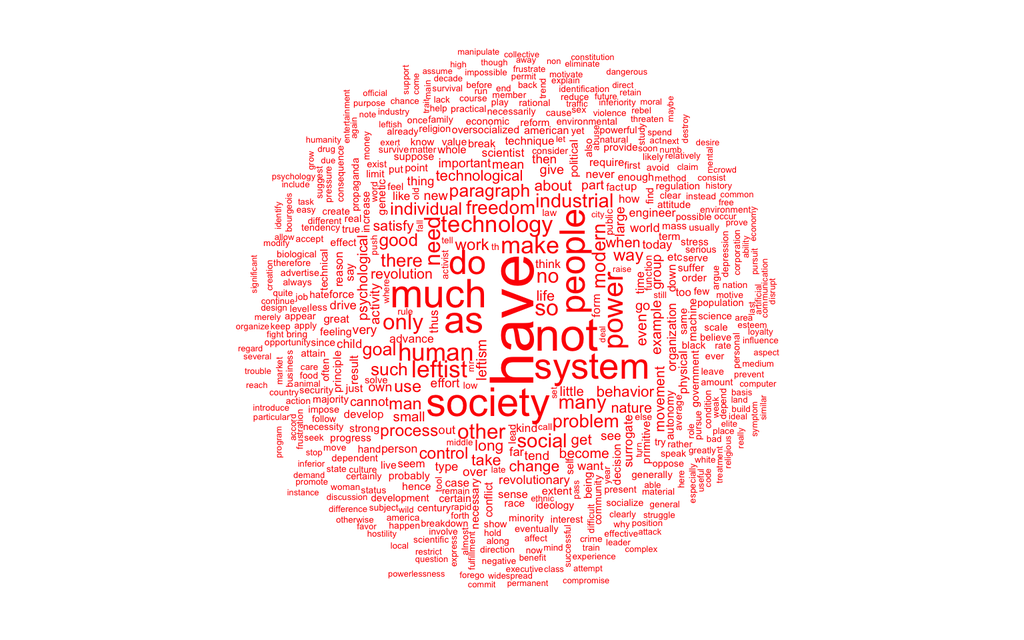

```r
quanteda.textplots::textplot_wordcloud(dfm_unabomb, random_order = FALSE, rotation = .25, color = "red")
```

## Histograms

Graphical display of a specific variable of interest in terms of its representation in the corpus, as a histogram.

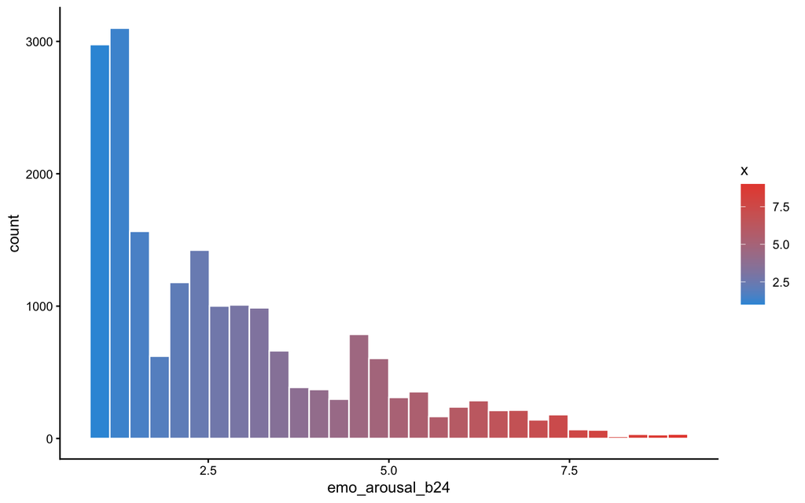

```r
df_prep %>%
  ggplot(aes(x = emo_arousal_b24, fill = after_stat(x))) +
  geom_histogram(color = "white") +
  scale_fill_gradient(low = "#3498db", high = "#e74c3c") +
  theme_classic()
```

## Intensity ratings across the corpus

Tracking a variable of interest over the span of the corpus.

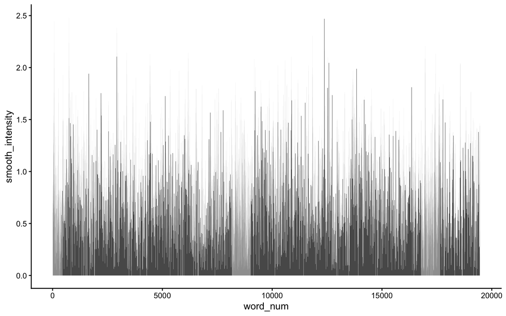

```r
df_prep %>% mutate(smooth_intensity = zoo::rollmean(emo_intensity, k = 5, fill = NA),
                             word_num = row_number()) %>%
  ggplot(mapping = aes(x = word_num, y = smooth_intensity)) +
  geom_col(position = "dodge") +
  theme_classic()
```

## Correlation plot

Correlation plots can show general trends of relationships between variables:

```r
library(Hmisc)
library(reshape)

cor_df <- df_prep %>%
  select(-text)

get_upper_tri <- function(cormat){
    cormat[lower.tri(cormat)]<- NA
    return(cormat)
}

cormat <- rcorr(as.matrix(cor_df))
cormat_r <- cormat$r
cormat_r_upper <- get_upper_tri(cormat_r)
cormat_r_melt <- melt(cormat_r_upper, na.rm = TRUE)
names(cormat_r_melt)[3] <- "correlation"


cormat_r_melt %>%
  ggplot(mapping = aes(x = X1, y = X2, fill = correlation)) +
  geom_tile(color = "black") +
  scale_fill_gradient2(low = "blue", high = "red", mid = "white",
   midpoint = 0, limit = c(-1, 1), space = "Lab",
   name="Correlation") +
  theme_minimal() +
  theme(axis.text.x = element_text(angle = 45, vjust = 1,
    size = 5, hjust = 1),
    axis.text.y = element_text(size = 5))+
 coord_fixed()
```

[output not shown]

## Line graphs

These line graphs track a variable of interest over the course of the corpus in a linear representation.

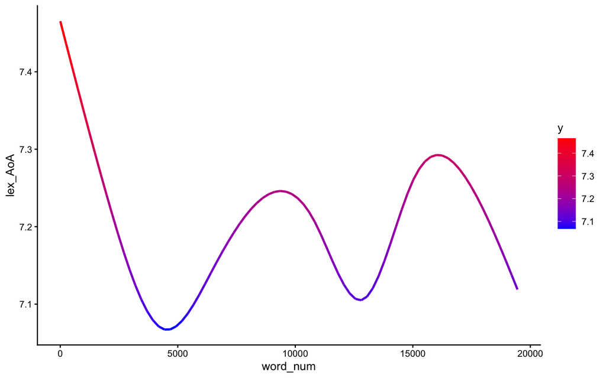

```r
df_prep %>%
  mutate(word_num = row_number()) %>%
  ggplot(mapping = aes(x = word_num, y = lex_AoA)) +
  geom_smooth(se = FALSE,
              aes(color = after_stat(y))) +
  scale_color_gradient(low = "blue", high = "red") +
  theme_classic()
```

# TEXT MESSAGE ANALYSIS FUNCTIONS

## Process raw text files from imessage-exporter tool on GitHub

imessage-exporter tool can be accessed through here: https://github.com/ReagentX/imessage-exporter. This tool will provide raw txt files that this function is designed to take natively.

```r
#file is a path to a raw txt file extracted using imessage-exporter
#will return one line per message, not one line per word
process_txt <- function(file, speaker_name, remove_attach = TRUE) {

  text_raw <- readLines(file)
  text_raw_df <- data.frame(raw_text = text_raw)
  text_df <- text_raw_df %>%
    mutate(chunk_id = cumsum(raw_text == ""), #identify chunks of text in txt file
           reply_text = case_when(
             grepl(pattern = "    ", x = raw_text) == TRUE ~ 0,
             TRUE ~ 1
           )) %>%
    filter(raw_text != "" &
             reply_text == 1) %>%
    group_by(chunk_id) %>%
    summarize(
      full_content = paste(raw_text, collapse = "\n"),
      .groups = "drop"
    ) %>%
    filter(full_content != "This message responded to an earlier message.") #filter some unwanted stuff

  #separate into lines
  text_df_split <- text_df %>%
    separate(full_content,
             into = c("time", "speaker", "text"),
             sep = "\n",
             extra = "merge") %>%
    mutate(text = gsub(pattern = "This message responded to an earlier message.",
                       replacement = "",
                       x = text),
           text = str_remove(pattern = "Tapbacks:\\D*",
                             string = text),
           time = str_remove(pattern = "\\s*\\(Read by.*?\\)",
                             string = time)) %>%
    filter(!is.na(text)) %>%
    mutate(attach_text = #filter out attachments
             case_when(
               grepl(pattern = "/Users/shawnwang/Library/Messages/Attachments\\d*D*", x = text) == TRUE ~ 0,
               TRUE ~ 1
             )) %>%
    { if(remove_attach == TRUE) filter(., attach_text == 1) else . } %>%
    #filter(attach_text == 1) %>%
    mutate(speaker = recode(speaker, Me = speaker_name), #recode speaker name
           datetime = strptime(time, format = "%b %d, %Y %I:%M:%S %p")) %>%
    select(speaker, text, datetime)

  #we only want two person conversations
  speakers <- unique(text_df_split$speaker)[1:2]

  if (length(speakers) == 1 | length(speakers) == 0 |
      is.na(speakers[[1]]) | is.na(speakers[[2]])) {
    return(tibble())
  }

  if (str_detect(string = speakers[1], pattern = "\\+") |
      str_detect(string = speakers[2], pattern = "\\+")) {

    return(tibble())
  }


  #create recipient
  text_df_names <- text_df_split %>%
    mutate(recipient = case_when(
      speaker == speakers[1] ~ speakers[2],
      speaker == speakers[2] ~ speakers[1],

    ))



  return(text_df_names)

}
```

## Calculate reaction time

This function calculates ratios of response times between two partners in a text message conversation.

```r
calc_rt_ratio <- function(sentences,
                          sec_threshold = 172800, #we assume by default 2 day gaps
                          speaker_str,
                          arrange_by = "median") {




  data_prep <- sentences %>%
    group_by(convo_num) %>%
    mutate(prev_gap = as.numeric(difftime(datetime,
                                          lag(datetime, default = first(datetime)),
                                          units = "secs")), #create time differences
           new_turn = speaker != lag(speaker, default = first(speaker)) | #indicate new turns
             prev_gap > sec_threshold,
           turn_id = cumsum(new_turn)) %>%  #identify new turns
    group_by(convo_num, turn_id) %>%
    summarize(speaker = first(speaker, na_rm = TRUE),
              recipient = first(recipient, na_rm = TRUE),
              turn_start = min(datetime),
              turn_end = max(datetime),
              message_count = n(),
              .groups = "drop_last") %>%
    filter(!is.na(turn_start)) %>%
    group_by(convo_num) %>%
    mutate(response_timestamp = lead(turn_start), #calculate response times
           response_time = difftime(response_timestamp,
                                    turn_end,
                                    units = "secs"),
           exchange_id = cumsum(ifelse(response_time > sec_threshold, 1, 0)),
           exchange_id = lag(exchange_id,
                             default = first(exchange_id))) %>%
    group_by(convo_num, exchange_id) %>%
    mutate(valid_response_time = ifelse(response_time > sec_threshold,
                                        NA,
                                        response_time)) #identify which ones are the ends of convos



  data_sum <- data_prep %>%
    group_by(convo_num, recipient) %>%
    summarize(mean_rt = mean(valid_response_time, na.rm = TRUE), #calculate means and medians
              median_rt = median(valid_response_time, na.rm = TRUE),
              message_count = sum(message_count),
              num_exchanges = max(exchange_id, na.rm = TRUE)) %>%
    ungroup() %>%
    mutate(mean_rt = ifelse(is.nan(mean_rt), NA, mean_rt),
           median_rt = ifelse(is.nan(median_rt), NA, median_rt)) %>%
    filter(!is.na(mean_rt))




  data_rt_ratio <- data_sum %>% #calculate the ratios
    group_by(convo_num) %>%
    filter(!is.na(recipient)) %>%
    filter(n() == 2) %>%
    summarize(
      rt_shawn_mean = mean_rt[recipient == speaker_str],
      rt_shawn_median = median_rt[recipient == speaker_str],
      rt_other_mean = mean_rt[recipient != speaker_str],
      rt_other_median = median_rt[recipient != speaker_str],
      num_messages_recipient = unique(message_count[recipient != speaker_str]),

      rt_ratio_mean = rt_other_mean/rt_shawn_mean,
      rt_ratio_mean_log = log(rt_other_mean) - log(rt_shawn_mean),
      rt_ratio_median = rt_other_median / rt_shawn_median,
      other_recipient = first(recipient[recipient != speaker_str]),
      .groups = "drop"
    ) %>%
    relocate(convo_num, other_recipient, rt_ratio_mean, rt_ratio_median)


  if (arrange_by == "median") {
    final_data <- data_rt_ratio %>%
      arrange(desc(rt_ratio_median))
  } else if (arrange_by == "mean") {
    final_data <- data_rt_ratio %>%
      arrange(desc(rt_ratio_mean))
  }

  return(final_data)


}
```

## Plotting sentiment over time

This function plots any number of sentiment values between two people in a conversational dyad over the time of the conversation.

```r
plot_convo <- function(data, people, sentiment) {

  sent_label <- sentiment

  data_prep <- data %>%
    filter(!is.na(word_clean)) %>%
    filter(speaker %in% people & recipient %in% people) %>% #filter dataset to only the two speakers
    left_join(small_lookup, by = c("word_clean" = "word")) #join to dataset




  plot <- data_prep %>%
    mutate(sentiment_z = scale(.data[[sentiment]])) %>% #scale sentiments to be on same scale for plotting
    ggplot(mapping = aes(x = datetime, y = sentiment_z, color = speaker)) +
    geom_smooth(se = FALSE) +
    scale_color_manual(values = setNames(c("forestgreen", "red"), people)) +
    labs(
      y = sent_label
    )

  return(plot)
}
```

## Calculate Down Bad Index

This function takes a number of helper functions and weights them to create an average summary value of dyadic behavioral asymmetry.

```r
dbi <- function(df,
                speaker_str,
                sec_threshold = 172800,
                message_threshold = NA,
                date_threshold = NA,
                date_max = NA,
                weights) {


  if (!is.list(weights)) {
    stop("weights must be a list")
  }

  expected <- c("word_ratio_log_z", "message_ratio_log_z", "end_ratio_log_z",
                "init_ratio_log_z", "rt_ratio_median_log_z") #we need to specify weights for fn
  if (!all(names(weights) %in% expected)) {
    stop("weights names must match: ", paste(expected, collapse = ", "))
  }
  if (round(sum(unlist(weights)), 10) != 1) {
    stop("weights must sum to 1")
  }



  #run the individual functions to create ratios
  #these individual functions do the heavy lifting
  sentence_cleaned <- prepare_sentences(df,
                                        date_threshold = date_threshold,
                                        date_max = date_max,
                                        message_threshold = message_threshold)


  rt_ranking <- calc_rt_ratio(sentences = sentence_cleaned,
                              speaker_str = speaker_str,
                              sec_threshold = sec_threshold)



  init_convo_ranking <- calc_init_ratio(sentences = sentence_cleaned,
                                        speaker_str = speaker_str,
                                        sec_threshold = sec_threshold)


  end_convo_ranking <- calc_end_ratio(sentences = sentence_cleaned,
                                      speaker_str = speaker_str,
                                      sec_threshold = sec_threshold)


  word_ratio_ranking <- word_message_ratio(sentences = sentence_cleaned,
                                           speaker_str = speaker_str)


  #join all the ratio datasets together
  join_list <- list(word_ratio_ranking, end_convo_ranking, init_convo_ranking, rt_ranking)

  joined_df <- reduce(join_list, full_join, by = c("other_recipient", "convo_num")) %>%
    select(convo_num, other_recipient, word_ratio, message_ratio, end_ratio,
           init_ratio, rt_ratio_mean, rt_ratio_median, speaker_messages, other_messages)

  #log transform to get out of ratio scale
  joined_df_log <- joined_df %>%
    mutate(across(c(word_ratio, message_ratio, end_ratio,
                    init_ratio, rt_ratio_mean, rt_ratio_median),
                  ~ log(.x),
                  .names = "{.col}_log"))

  #z score to standardize across all variables
  joined_df_z <- joined_df_log %>%
    mutate(across(c(word_ratio_log, message_ratio_log, end_ratio_log,
                    init_ratio_log, rt_ratio_mean_log, rt_ratio_median_log),
                  ~ .x / sd(.x, na.rm = TRUE), #z score WITHOUT centering
                  .names = "{.col}_z"))


  #join the dataset together
  final_df <- joined_df_z %>%
    mutate(dbi = rowSums(across(names(weights),
                                ~ .x * weights[[cur_column()]]))) %>%
    arrange(desc(dbi)) %>%
    relocate(other_recipient, dbi)



  return(final_df)

}
```

## Calculate initiation ratio

This is an example of one of those helper functions utilized by the dbi function in order to calculate the number of conversations initiated by each person in a conversational dyad.

```r
calc_init_ratio <- function(sentences,
                            sec_threshold = 172800,
                            speaker_str) {



  #calculate turns and response times just like before
  data_prep <- sentences %>%
    group_by(convo_num) %>%
    mutate(prev_gap = as.numeric(difftime(datetime,
                                          lag(datetime, default = first(datetime)),
                                          units = "secs")),
           new_turn = speaker != lag(speaker, default = first(speaker)) |
             prev_gap > sec_threshold,
           turn_id = cumsum(new_turn)) %>%
    group_by(convo_num, turn_id) %>%
    summarize(speaker = first(speaker, na_rm = TRUE),
              recipient = first(recipient, na_rm = TRUE),
              turn_start = min(datetime),
              turn_end = max(datetime),
              message_count = n(),
              .groups = "drop_last") %>%
    filter(!is.na(turn_start)) %>%
    group_by(convo_num) %>%
    mutate(response_timestamp = lead(turn_start),
           response_time = difftime(response_timestamp,
                                    turn_end,
                                    units = "secs"),
           exchange_id = cumsum(ifelse(response_time > sec_threshold, 1, 0)),
           exchange_id = lag(exchange_id,
                             default = first(exchange_id)))


  #count how many times each person starts a conversation
  data_calc <- data_prep %>%
    group_by(convo_num, exchange_id) %>%
    summarize(speaker_init = first(speaker),
              init_message_count = first(message_count)) %>%
    group_by(convo_num, speaker_init) %>%
    summarize(num_init = n()) %>%
    group_by(convo_num) %>%
    filter(n() == 2)

  #summarize into ratios
  data_ratio <- data_calc %>%
    group_by(convo_num) %>%
    summarize(init_speaker = num_init[speaker_init == speaker_str],
              init_other = num_init[speaker_init != speaker_str],

              init_ratio = init_speaker / init_other,
              other_recipient = first(speaker_init[speaker_init != speaker_str]),
              .groups = "drop") %>%
    arrange(desc(init_ratio))

  return(data_ratio)



}
```